# **STATS 503, Homework 10: Neural Networks and Gradient Descent for Classification**

**Submission instructions:** Upon completion, please run the entire notebook, export the notebook and output as html, and upload this html to Canvas.

# Part 1: Textbook exercises

1. ISLP chapter 10 exercise #1, parts (a), (b), and (d)
2. ISLP chapter 10 exercise #2
3. ISLP chapter 10 exercise #4, parts (b) (c) and (d)
4. ISLP chapter 10 exercise #6

**1a.**

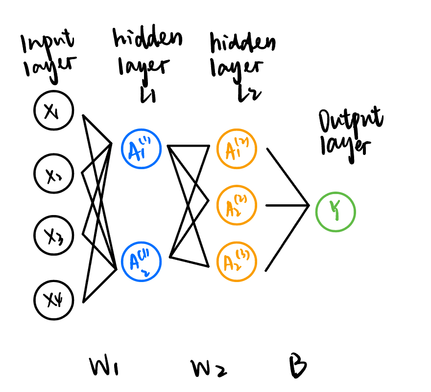

**1b.**

Let the input vector be:

$$ X = \begin{pmatrix} X_1 \\ X_2 \\ X_3 \\ X_4 \end{pmatrix} \in \mathbb{R}^4 $$

Define the ReLU activation function as:

$$ \text{ReLU}(z) = \max(0, z) $$

Let the weight matrices and bias vectors be:

$$ W^{[1]} \in \mathbb{R}^{2 \times 4}, \quad b^{[1]} \in \mathbb{R}^2 $$$$ W^{[2]} \in \mathbb{R}^{3 \times 2}, \quad b^{[2]} \in \mathbb{R}^3 $$$$ W^{[3]} \in \mathbb{R}^{1 \times 3}, \quad b^{[3]} \in \mathbb{R} $$

The network is defined layer by layer as follows:

First hidden layer:

$$ Z^{[1]} = W^{[1]} X + b^{[1]} $$$$ A^{[1]} = \text{ReLU}(Z^{[1]}) = \max(0, Z^{[1]}) \quad \text{(applied elementwise)} $$

Second hidden layer:

$$ Z^{[2]} = W^{[2]} A^{[1]} + b^{[2]} $$$$ A^{[2]} = \text{ReLU}(Z^{[2]}) = \max(0, Z^{[2]}) $$

Output layer:

$$ Z^{[3]} = W^{[3]} A^{[2]} + b^{[3]} $$$$ f(X) = Z^{[3]} \in \mathbb{R} $$

Overall, the expression for the output of the network is:

$$ f(X) = W^{[3]} \cdot \max\left(0,\; W^{[2]} \cdot \max\left(0,\; W^{[1]} X + b^{[1]} \right) + b^{[2]} \right) + b^{[3]} $$

**1d.**

We count the number of parameters as the total number of weights and biases in the network:

- Layer 1 (Input layer to first hidden layer):
  - Weight matrix $W^{[1]} \in \mathbb{R}^{2 \times 4}$: $2 \times 4 = 8$ parameters
  - Bias vector $b^{[1]} \in \mathbb{R}^2$: 2 parameters
- Layer 2 (First hidden layer to second hidden layer):
  - Weight matrix $W^{[2]} \in \mathbb{R}^{3 \times 2}$: $3 \times 2 = 6$ parameters
  - Bias vector $b^{[2]} \in \mathbb{R}^3$: 3 parameters
- Layer 3 (Second hidden layer to output):
  - Weight matrix $W^{[3]} \in \mathbb{R}^{1 \times 3}$: $1 \times 3 = 3$ parameters
  - Bias term $b^{[3]} \in \mathbb{R}$: 1 parameter

Total number of parameters:

$$ 8 + 2 + 6 + 3 + 3 + 1 = 23 $$

**2a.**

Given the softmax function from (10.13):

$$ f_m(X) = \Pr(Y = m \mid X) = \frac{e^{Z_m}}{\sum_{\ell = 0}^{9} e^{Z_\ell}} $$

Now suppose we add a constant $c$to each $Z_\ell$, defining $\tilde{Z}_\ell = Z_\ell + c$. Then the new softmax becomes:

$$ \tilde{f}_m(X) = \frac{e^{Z_m + c}}{\sum_{\ell = 0}^{9} e^{Z_\ell + c}} = \frac{e^{Z_m} e^{c}}{e^{c} \sum_{\ell = 0}^{9} e^{Z_\ell}} = \frac{e^{Z_m}}{\sum_{\ell = 0}^{9} e^{Z_\ell}} = f_m(X) $$

**2b.**

From (4.13), the class probability for class $k$ is:

$$ \Pr(Y = k \mid X = x) = \frac{e^{\beta_{k0} + \beta_{k1} x_1 + \cdots + \beta_{kp} x_p}}{\sum_{\ell = 1}^{K} e^{\beta_{\ell 0} + \beta_{\ell 1} x_1 + \cdots + \beta_{\ell p} x_p}} $$

Now suppose we add constants $c_j$ to each corresponding coefficient across all classes, so:

$$ \tilde{\beta}_{kj} = \beta_{kj} + c_j, \quad \text{for all } j = 0, 1, \dots, p $$

Then the numerator becomes:

$$ e^{\sum_{j=0}^p \tilde{\beta}_{kj} x_j} = e^{\sum_{j=0}^p (\beta_{kj} + c_j)x_j} = e^{\sum_{j=0}^p \beta_{kj} x_j + \sum_{j=0}^p c_j x_j} = e^{\sum_{j=0}^p \beta_{kj} x_j} \cdot e^{\sum_{j=0}^p c_j x_j} $$

Similarly, the denominator becomes:

$$ \sum_{\ell=1}^{K} e^{\sum_{j=0}^p \beta_{\ell j} x_j} \cdot e^{\sum_{j=0}^p c_j x_j} = e^{\sum_{j=0}^p c_j x_j} \cdot \sum_{\ell=1}^{K} e^{\sum_{j=0}^p \beta_{\ell j} x_j} $$

Therefore, the softmax becomes:

$$ \tilde{\Pr}(Y = k \mid X = x) = \frac{e^{\sum_{j=0}^p \beta_{kj} x_j} \cdot e^{\sum_{j=0}^p c_j x_j}}{e^{\sum_{j=0}^p c_j x_j} \cdot \sum_{\ell=1}^{K} e^{\sum_{j=0}^p \beta_{\ell j} x_j}} = \frac{e^{\sum_{j=0}^p \beta_{kj} x_j}}{\sum_{\ell=1}^{K} e^{\sum_{j=0}^p \beta_{\ell j} x_j}} $$

**4b.**

$$ 3\times(5\times 5+1)=78 $$

**4c.**

- The input image has size $32 \times 32 = 1024$ pixels, so the input layer has 1024 units.
- Each $5 \times 5$ filter slides over the image with stride 1 and no padding (valid convolution).
- The output spatial size is:

$$ 32 - 5 + 1 = 28 \quad \Rightarrow \quad 28 \times 28 = 784 \text{ activations per filter} $$

- With 3 filters, we get $784 \times 3 = 2352$ hidden units.

Thus, the CNN is equivalent to an FCN with:

- Input layer: 1024 units
- Hidden layer: 2352 units

**4d.**

If we remove the local connectivity and weight sharing constraints, then this becomes a regular fully connected network with:

- Input: 1024 units
- Hidden: 2352 units

Each hidden unit has 1024 weights + 1 bias. So total parameters:

Total:

$$ 1024 \times 2352 + 2352 = 2410800 $$

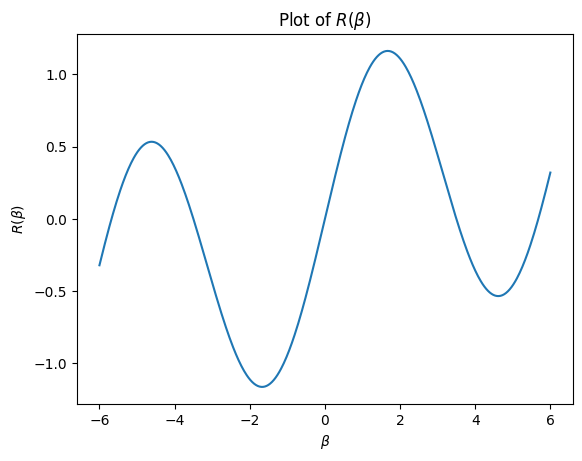

```python
import numpy as np
import matplotlib.pyplot as plt

def R(beta):
    return np.sin(beta)+beta/10

beta_val = np.linspace(-6, 6, 500)
R_val = R(beta_val)

plt.plot(beta_val, R_val, label=r'$R(\beta) = \sin(\beta) + \frac{\beta}{10}$')
plt.xlabel(r'$\beta$')
plt.ylabel(r'$R(\beta)$')
plt.title(r'Plot of $R(\beta)$')
plt.show()
```

**6b.** $$ R'(\beta)= \cos(x)+1/10 $$

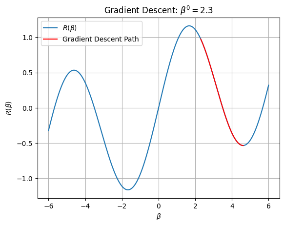

```
Final β: 4.6122, R(β): -0.5338, Steps: 130
```

```python
# 6c

def R_prime(beta):
    return np.cos(beta) + 0.1

lr = 0.1
beta = 2.3
threshold = 1e-6
betas = [beta]

for i in range(500):
    grad = R_prime(beta)
    beta_new = beta - lr * grad
    betas.append(beta_new)
    if abs(beta_new - beta) < threshold:
        break
    beta = beta_new

plt.plot(beta_val, R_val, label=r'$R(\beta)$')
plt.plot(betas, R(np.array(betas)), c='red', label='Gradient Descent Path')
plt.xlabel(r'$\beta$')
plt.ylabel(r'$R(\beta)$')
plt.title(r'Gradient Descent: $\beta^0 = 2.3$')
plt.legend()
plt.grid(True)
plt.show()

print(f'Final β: {betas[-1]:.4f}, R(β): {R(betas[-1]):.4f}, Steps: {len(betas)}')
```

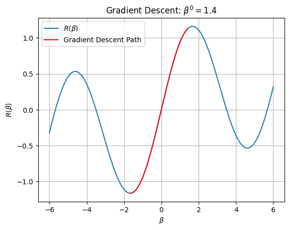

```
Final β: -1.6710, R(β): -1.1621, Steps: 140
```

```python
def R_prime(beta):
    return np.cos(beta) + 1/10

lr = 0.1
beta = 1.4
threshold = 1e-6
betas = [beta]

for i in range(500):
    grad = R_prime(beta)
    beta_new = beta - lr * grad
    betas.append(beta_new)
    if abs(beta_new - beta) < threshold:
        break
    beta = beta_new

plt.plot(beta_val, R_val, label=r'$R(\beta)$')
plt.plot(betas, R(np.array(betas)), c='red', label='Gradient Descent Path')
plt.xlabel(r'$\beta$')
plt.ylabel(r'$R(\beta)$')
plt.title(r'Gradient Descent: $\beta^0 = 1.4$')
plt.legend()
plt.grid(True)
plt.show()

print(f'Final β: {betas[-1]:.4f}, R(β): {R(betas[-1]):.4f}, Steps: {len(betas)}')
```

# Part 2: Multiclass Logistic Regression

In this part, we'll train a multiclass logistic regression module using gradient descent.

## Problem 1: One-hot encodings for multi-class data

If we have a vector $y'$ with dimensions $n \times 1$ that contains $m$ class labels stored in $l$ with dimensions $m \times 1$, the one-hot encoding is an $n \times m$ matrix $Y$ where $Y_{ij}$ is 1 if $z_i = l_j$ and 0 otherwise.

For example, if \begin{align*} y' = \begin{bmatrix} \textrm{Sahana} \\ \textrm{Eduardo} \\ \textrm{Jake} \\ \textrm{Eduardo} \\ \textrm{Jake} \\ \textrm{Jake} \\ \textrm{Eduardo} \end{bmatrix} \text{ and } l = \begin{bmatrix} \textrm{Sahana} \\ \textrm{Eduardo} \\ \textrm{Jake} \end{bmatrix}, \end{align*} then \begin{align*} Y = \begin{bmatrix} 1 & 0 & 0 \\ 0 & 1& 0\\ 0 & 0 & 1\\ 0 & 1& 0\\ 0 & 0 & 1\\ 0 & 0 & 1\\ 0 & 1 & 0 \end{bmatrix} . \end{align*}

You can think of the first column as indiciating whether $y'_i$ is Sahana, the second column as indiciating whether $y'_i$ is Eduardo, and third column as indiciating whether $y'_i$ is Jake.

Write a function that converts class labels to a one-hot encoding without using for (or while) loops across observations; loops across observations will be very time consuming when the sample size grows. Instead, you should use numpy vectorization. Loops iterating over the number of distinct labels are fine as the number of distinct labels is typically small.

Your function should return $Y$ (an $n \times m$ array) given $y'$ ($n \times 1$) and labels $l$ ($m \times 1$). You may use numpy's `where` function in your implementation. The code block below contains further instructions.

```python
import numpy as np
import pandas as pd
import matplotlib.pyplot as plt
import scipy.stats as stats

# this part loads the iris dataset from sklearn and splits it
from sklearn.datasets import load_iris
from sklearn.model_selection import train_test_split

data_iris = load_iris()
X_iris = data_iris.data
y_iris = data_iris.target

# add the intercept/bias term to X
n, p = X_iris.shape
ones = np.ones((n, 1))
X_iris = np.hstack((ones, X_iris))
```

```python
#############################################################################
# TODO:                                                                     #
# Implement a one-hot encoding for a given y and l                          #
# Input: y_prime of shape (n, 1), l of shape (m, 1)                         #
# Output: Y of shape (n, m)                                                 #
#############################################################################

def one_hot_encoding(y_prime, l):
    # YOUR CODE HERE
    # using broadcasting
    return (y_prime == l.T).astype(int)
```

```python
# check answer -- please don't change this code
np.random.seed(42)
l = np.arange(3)
y_iris_check = y_iris.reshape((y_iris.shape[0], 1))[np.random.randint(150, size = 10)]
one_hot_y = one_hot_encoding(y_iris_check, l)
print(one_hot_y)
assert one_hot_y.shape == (10, 3)
```

```
[[0 0 1]
 [0 1 0]
 [1 0 0]
 [0 0 1]
 [0 1 0]
 [1 0 0]
 [0 0 1]
 [0 0 1]
 [0 1 0]
 [0 1 0]]
```

## Problem 2: Making predictions with multiclass logistic regression

A probabilistic classifier for multi-class data returns a length-$m$ vector of probabilities for each observation. Each entry of this vector is the probability of the observation belonging to the corresponding class. However, model outputs can take arbitrary values, so we should transform these outputs so that they are nonnegative and sum to 1.

The softmax is such a transformation. Suppose that $z_i = (z_{i1}, \ldots, z_{im})$ is the output of the model for data point $i$. The softmax function $\sigma$ is $$ \sigma(z_i) = \left[ \frac{e^{z_{i1}}}{\sum_{j=1}^m e^{z_{ij}}}, \ldots, \frac{e^{z_{im}}}{\sum_{j=1}^m e^{z_{ij}}}, \right]. $$

In multiclass logistic regression, the probability that an observation with features $x$ belongs to class $j$ is $$ p(y = j \mid x) = \sigma ( Wx ), $$ where $W$ is a matrix of parameters.

Write a function that takes an $n \times p$ design matrix 𝑋 and a $m \times p$ parameter matrix 𝑊 and returns the class probabilities for each observation according to multiclass logistic regression. Use only numpy functions (and not scipy) in your solution.

```python
def lr_predict(X, W):
    # YOUR CODE HERE
    wx = np.matmul(X, W.T)
    exp_wx = np.exp(wx)
    return exp_wx/np.sum(exp_wx, axis=1, keepdims=True)
```

```python
# check answer -- please don't change this code
n, p = X_iris.shape
m = l.shape[0]
np.random.seed(42)
W = np.random.randn(m, p)
P_hat = lr_predict(X_iris, W)
assert P_hat.shape == (n, m)
assert np.allclose(np.sum(P_hat, axis = 1), np.ones(n))
```

## Problem 3: Numerically stable prediction of log probabilities

One can naively implement the loss function for multiclass logistic regression by taking the log of `P_hat`, where `P_hat` is output from calling `lr_predict`. However, doing so can be numerically unstable if `P_hat` contains entries that are nearly zero; applying a log to a variable that is not guaranteed to be strictly positive is inadvisable.

To avoid this instability, let's compute the log of `P_hat` directly. To do so, we'll make use the log-sum-exp ($\mathrm{logsumexp}$) function: $$ \mathrm{logsumexp}(x_1, \ldots, x_k) = \log \left[ \sum_{j=1}^k \exp(x_j) \right]. $$ The definition explains its name: it's a sequence of log, sum ($\sum$), and exp. You can find a scipy version of this function [here](https://docs.scipy.org/doc/scipy/reference/generated/scipy.special.logsumexp.html).

Now, observe that $$ \log\sigma(z_i) = \left[ z_i - \log\left(\sum_{j=1}^m \exp(z_{ij})\right), \ldots, z_i - \log\left(\sum_{j=1}^m \exp(z_{ij})\right) \right]. $$

Write a function that takes a design matrix 𝑋 and parameter matrix 𝑊 and returns the log of the class probabilities for each observation according to multiclass logistic regression. You'll then use this function to write a numerically stable version of the loss function in the Problem 4.

```python
import scipy.special as special

def lr_predict_log(X, W):
    # YOUR CODE HERE
    z = np.matmul(X, W.T)
    log_softmax = z - special.logsumexp(z, axis=1, keepdims=True)
    return log_softmax
```

```python
# check answer -- please don't change this code
P_hat_log = lr_predict_log(X_iris, W)
assert P_hat_log.shape == (n, m)
assert np.allclose(np.sum(np.exp(P_hat_log), axis = 1), np.ones(n))
```

## Problem 4: Gradient descent for multiclass logistic regression

The loss function for the multiclass logistic regression is \begin{align*} L(W) &= -\sum_{i =1}^n \sum_{j = 1}^{m}Y_{ij} \log \widehat{P}_{ij} \end{align*} where $\widehat{P}$ is an $n \times m$ matrix containing the class probabilities (given the parameters $W$) and $Y$ is the one-hot encoding of the responses.

The gradient for the multiclass logistic regression loss is \begin{align*} \nabla L(W) &= [\widehat{P} - Y]^\intercal X. \end{align*}

Using this formula, implement gradient descent algorithm that will output optimal $W$ and the corresponding training loss. The input to your function is a matrix $X$ with dimensions $n \times p$, a vector $y$ with dimensions $n \times 1$, a learning rate $\eta$, a weight initalization $W_0$ for $W$, and an $\epsilon$ convergence threshold. The output should be a tuple containing the optimal weights and the loss value. Each iteration should call `lr_predict_log`.

```python
#############################################################################
# TODO:                                                                     #
# Implement Gradient Descent for Logistic Regression using the gradient.    #
# formula from above.                                                       #
# Input: X of shape (n, p), y of shape (n,), eta,                           #
#        initial_W of shape (m, (p + 1)), epsilon                           #
# Output: W of shape (m, (p + 1)) and Training loss using that weight.      #
#                                                                           #
# ONLY use numpy for this section, not scikit-learn!                        #
#############################################################################

def lr_train(X, y, eta, initial_W, epsilon):
    n, p = X.shape
    m = initial_W.shape[0]

    Y = np.zeros((n, m))
    Y[np.arange(n), y] = 1

    W = initial_W
    while True:
        # YOUR CODE HERE
        p_hat = lr_predict(X, W)
        p_log_hat = lr_predict_log(X, W)
        loss = -np.sum(Y * p_log_hat)
        loss_grad = np.matmul((p_hat - Y).T, X)
        W2 = W - eta * loss_grad
        if np.linalg.norm(W2 - W) < epsilon:
            W = W2
            break
        W = W2

    return W, loss
```

```python
# check answer -- please don't change this code
np.random.seed(42)

X_train_iris, X_test_iris, y_train_iris, y_test_iris = train_test_split(
    X_iris, y_iris, test_size=0.3, random_state=42
)

initial_W = np.random.randn(m, p)
eta = 1e-3
epsilon = 0.001
W_graddescent, training_loss = lr_train(X_train_iris, y_train_iris, eta, initial_W, epsilon)
print("The training loss is {}".format(training_loss))
assert(training_loss < 15 and training_loss > 5)
print("The weights are \n {}".format(W_graddescent))

pred_y_test = lr_predict_log(X_test_iris, W_graddescent)
new_Y_test = one_hot_encoding(y_test_iris.reshape((y_test_iris.shape[0], 1)), np.arange(m))
test_loss = -np.sum(np.multiply(pred_y_test, new_Y_test))
print("The test loss is {}".format(test_loss))
assert(test_loss < 5 and test_loss > 1)
```

```
The training loss is 9.807884356473995
The weights are
 [[ 1.17844033  1.14118556  3.82786982 -3.83901165 -2.62147555]
 [ 0.99112574  1.39964872  0.57121136 -0.89942374 -1.75365639]
 [-2.37040656 -1.56561552 -2.74199564  3.87871062  2.95862079]]
The test loss is 2.9828151552330864
```